# Learning objectives

1. You can write comments in R.
2. You know how to use R as a calculator.
3. You can create, overwrite and manipulate R objects.
4. You understand the syntax for calling R functions.
5. You can use install and load add-on R packages and call functions from these.

# 1 Introduction

In the last lesson, you learned how to use RStudio, the wonderful integrated development environment (IDE) that makes working with R much easier. In this lesson, you will learn the basics of using R itself.

To get started, open RStudio, and open a new script with `File > New File > R Script` on the RStudio menu.

Next, **save the script** with `File > Save` on the RStudio menu or by using the shortcut `Command`/`Control` + `S` . This should bring up the Save File dialog box. Save the file with a name like “coding_basics”.

You should now type all the code from this lesson into that script. You will be asked to submit these notes at the end of the lesson.

# 2 R is a calculator

R works as a calculator, and obeys the correct order of operations. Type and run the following expressions and observe their output:

```r
2 + 2
```

```
## [1] 4
```

```r
3 + 4 * 2   # this is evaluated following the order of operations
```

```
## [1] 11
```

```r
sqrt(100)   # square root
```

```
## [1] 10
```

The square root command shown on the last line is a good example of an R *function*, where `100` is the *argument* to the function. You will see more functions soon.

We hope you remember the shortcut to run code!

To **run a single line of code**, place your cursor anywhere on that line, then hit `Command` + `Enter` on macOS, or `Control` + `Enter` on Windows.

To **run multiple lines**, drag your cursor to highlight the relevant lines then again press `Command`/`Control` + `Enter`.

# 3 Formatting code

R does not care how you choose to space out your code.

For the math operations we did above, all the following would be valid code:

```r
2+2
```

```
## [1] 4
```

```r
2 + 2
```

```
## [1] 4
```

```r
2                +                   2
```

```
## [1] 4
```

Similarly, for the `sqrt()` function used above, any of these would be valid:

```r
sqrt(100)
```

```
## [1] 10
```

```r
sqrt(    100     )
```

```
## [1] 10
```

```r
# you can even space the command out over multiple lines
sqrt(
  100
    )
```

```
## [1] 10
```

But of course, you should try to space out your code in sensible ways. What exactly is “sensible”? Well, it may be hard for you to know at the moment. Over time, as you read other people’s code, you will learn that there are certain R *conventions* for code spacing and formatting.

In the meantime, you can ask RStudio to help format your code for you. To do this, highlight any section of code you want to reformat, and, on the RStudio menu, go to `Code > Reformat Code`, or use the shortcut `Shift` + `Command/Control` + `A`.

# 4 Objects in R

## 4.1 Create an object

When you run code as done above, the result of the code (or *value*) is simply displayed in the console—it is not stored anywhere.

```r
2 + 2 # R prints this result, 4, but does not store it
```

```
## [1] 4
```

To store a value for future use, assign it to an *object* with the *assignment operator**,*** `<-` :

```r
my_obj <- 2 + 2 # assign the result of `2 + 2 ` to the object called `my_obj`
my_obj # print my_obj
```

```
## [1] 4
```

The assignment operator, `<-` , is made of the ‘less than’ sign, `<` , and a minus, `-`. You will use it thousands of times over your R lifetime, so please don’t type it manually! Instead, use RStudio’s shortcut, **`alt`** + **`-`** (**alt** AND **minus**) on Windows or **`option`** + **`-`** (**option** AND **minus**) on macOS.

Also note that you can use the *equals* sign, `=`, for assignment.

```r
my_obj = 2 + 2
```

And you can even use the *forward assignment* operator:

```r
2 + 2 -> my_obj
```

But both of these are not commonly used by the R community (mostly for historical reasons), so we discourage using them. Follow the convention and use `<-`.

Now that you’ve created the object `my_obj`, R knows all about it and will keep track of it during this R session. You can view any created objects in the *Environment* tab of RStudio.

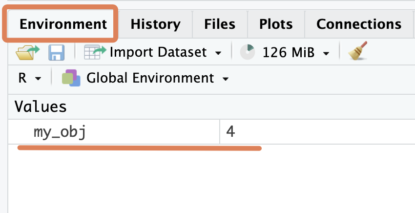

R is case-sensitive. You have now defined `my_obj`, with a lowercase “m”. If you try to print `My_obj`, with a capital “M”, you will get an error message.

```r
my_obj
```

```
## [1] 4
```

```r
My_obj
```

```
Error: object 'My_obj' not found
```

So pay attention to capitalization!

## 4.2 Create a character object

Let’s create another R object, `my_obj2` and assign it the value `"R is cool"`, which is a *string*.

```r
my_obj2 <- "R is cool"
```

Notice that character strings, such as “R is cool”, must be placed within quotes. If you forget the quotes you will receive an error message:

```r
my_obj2 <- R is cool
```

```
Error: unexpected symbol in "my_obj2 <- R is"
```

Your workspace now contains both objects you’ve created, `my_obj` and `my_obj2`.

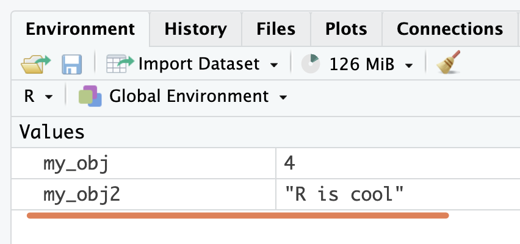

## 4.3 Overwrite or rename objects

To change, or *overwrite*, the value of an existing object, you simply assign a new value to it. For example, to change the value of `my_obj2` from `"R is cool"` to the number `1024` , run:

```r
my_obj2 <- 1024
```

Notice that `my_obj2`’s type, as shown in the Environment pane, has now changed to “numeric”, and the value has changed to 1024:

[figure not shown]

To rename an object, you make a copy of the object, with a new name, and delete the original. So, if you want to rename `my_obj` to `your_obj`, type:

```r
your_obj <- my_obj # make a copy of `my_obj`, called `your_obj`
```

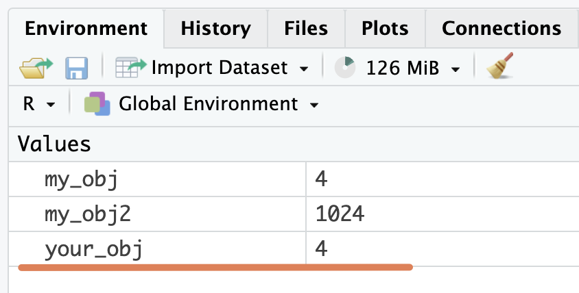

Then:

```r
rm(my_obj) # delete `my_obj`
```

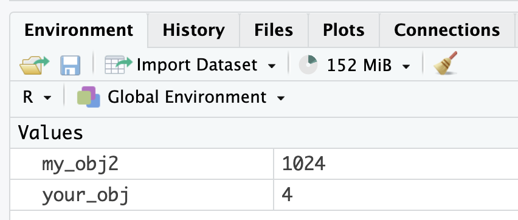

## 4.4 Manipulate objects

Just as you were able to take the square root of a number earlier (`sqrt(100)`), you can manipulate or *do things to* objects you have created.

For example, try taking the square root of `my_obj2`:

```r
sqrt(my_obj2)
```

```
## [1] 32
```

Nice! R “sees” `my_obj2` as the number 1024, and so is able to evaluate it’s square root.

You can also combine existing objects to create new objects. For example, type out the code below to add `my_obj2` to itself and assign the result to a new object, `my_obj3`.

```r
my_obj3 <- my_obj2 + my_obj2
my_obj3
```

```
## [1] 2048
```

## 4.5 Some errors with objects

```r
char_obj <- "hello"
char_obj2 <- "world!"
char_obj3 <- char_obj + char_obj2
```

```
Error in char_obj + char_obj2 : non-numeric argument to binary operator
```

The error message tells you that these objects are not numbers and therefore cannot be added with `+`. This is a fairly common error type, caused by trying to do inappropriate things to your objects. Be careful about this.

Another error you’ll get a lot is `Error: object 'XXX' not found`. For example:

```r
my_obj <- 48 # define `my_obj`
My_obj + 2 # attempt to add 2 to `my_obj`
```

```
Error: object 'My_obj' not found
```

Here, R returns an error message because we haven’t created (or *defined*) the object `My_obj` yet. (Recall that R is case-sensitive.)

When you first start learning R, dealing with errors can be frustrating. They’re often difficult to understand (e.g. what exactly does “*non-numeric argument to binary operator*” mean?).

Try Googling any error messages you get and browsing through the first few results. This will lead you to forums (e.g. stackoverflow.com) where other R learners have complained about the same error. Here you may find explanations of, and solutions to, your problems.

## 4.6 Datasets are objects too

So far, you have been working with very simple objects. You may be thinking “Where are the spreadsheets and datasets? Why are we writing `my_obj <- 2 + 2`? Is this a primary school maths class?!”

Be patient.

We want you to get familiar with the concept of an R object because once you start dealing with real datasets, these will also be stored as R objects.

Let’s see a preview of this now. Type out the code below to take the Ebola dataset that is in the `{outbreaks}` package and store it in the object `ebola_data`.

```r
ebola_data <- outbreaks::ebola_sierraleone_2014
ebola_data ## print ebola_data
```

```
##    id age sex    status date_of_onset date_of_sample district    chiefdom
## 1   1  20   F confirmed    2014-05-18     2014-05-23 Kailahun  Kissi Teng
## 2   2  42   F confirmed    2014-05-20     2014-05-25 Kailahun  Kissi Teng
## 3   3  45   F confirmed    2014-05-20     2014-05-25 Kailahun Kissi Tonge
## 4   4  15   F confirmed    2014-05-21     2014-05-26 Kailahun  Kissi Teng
## 5   5  19   F confirmed    2014-05-21     2014-05-26 Kailahun  Kissi Teng
## 6   6  55   F confirmed    2014-05-21     2014-05-26 Kailahun  Kissi Teng
## 7   7  50   F confirmed    2014-05-21     2014-05-26 Kailahun  Kissi Teng
## 8   8   8   F confirmed    2014-05-22     2014-05-27 Kailahun  Kissi Teng
## 9   9  54   F confirmed    2014-05-22     2014-05-27 Kailahun  Kissi Teng
## 10 10  57   F confirmed    2014-05-22     2014-05-27 Kailahun  Kissi Teng
```

If you get an error like “Error in loadNamespace(x) : there is no package called ‘outbreaks’”, it means you have not installed the `outbreaks` package, which you should have done in the previous lesson. Do this now in the Packages tab. Click the Install icon, type in **outbreaks**, and click “Install”.

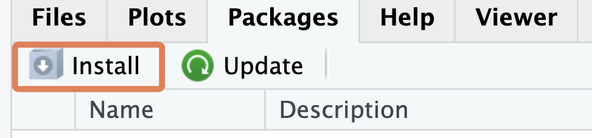

```r
ebola_data + my_obj2
```

```
## Warning in Ops.factor(left, right): '+' not meaningful for factors

## Warning in Ops.factor(left, right): '+' not meaningful for factors

## Warning in Ops.factor(left, right): '+' not meaningful for factors

## Warning in Ops.factor(left, right): '+' not meaningful for factors
```

```
##      id  age sex status date_of_onset date_of_sample district chiefdom
## 1  1025 1044  NA     NA    2017-03-07     2017-03-12       NA       NA
## 2  1026 1066  NA     NA    2017-03-09     2017-03-14       NA       NA
## 3  1027 1069  NA     NA    2017-03-09     2017-03-14       NA       NA
## 4  1028 1039  NA     NA    2017-03-10     2017-03-15       NA       NA
## 5  1029 1043  NA     NA    2017-03-10     2017-03-15       NA       NA
## 6  1030 1079  NA     NA    2017-03-10     2017-03-15       NA       NA
## 7  1031 1074  NA     NA    2017-03-10     2017-03-15       NA       NA
## 8  1032 1032  NA     NA    2017-03-11     2017-03-16       NA       NA
## 9  1033 1078  NA     NA    2017-03-11     2017-03-16       NA       NA
## 10 1034 1081  NA     NA    2017-03-11     2017-03-16       NA       NA
```

Looks like it sort of worked! Because you added 1024 to the whole dataset, you increased everyone’s “age” and “id” by 1024, and shifted all the dates forward by 1024 days. But for the character columns, such as “sex”, adding 1024 was not possible, so we were left with NAs (which means “not applicable” or “not available”, and some helpful warnings.

## 4.7 Naming objects

> There are only *two hard things* in Computer Science: cache invalidation and *naming things*.

> — Phil Karlton.

Because much of your work in R involves interacting with objects you have created, picking intelligent names for these objects is important.

Naming objects is difficult because names should be both **short** (so that you can type them quickly) and **informative** (so that you can easily remember what is inside the object), and these two goals are often in conflict.

So names that are too long, like the one below, are bad because they take forever to type.

```r
ebola_outbreak_dataset_from_sierra_leone_in_2014
```

And a name like `data` is bad because it is not informative; the name does not give a good idea of what the object is.

As you write more R code, you will learn how to write short and informative names.

For names with multiple words, there are a few conventions for how to separate the words:

```r
snake_case <- "Snake case uses underscores"
period.case <- "Period case uses periods"
camelCase <- "Camel case capitalize new words (but not the first word)"
```

We recommend snake_case, which uses all lower-case words, and separates words with `_`.

There are also a few limitations on objects’ names:

- names must start with a letter. So `2014_data` is not a valid name (because it starts with a number).
- names can only contain letters, numbers, periods (`.`) and underscores (`_`). So `ebola-data` or `ebola~data` are not valid names.

Finally, avoid giving your object the same name as a built-in function or value. For example, “data” is a built-in function in R (try running `data()` to see this). So don’t name your objects “data”.

# 5 Functions

Much of your work in R will involve calling *functions*.

A function is a named section of code that can be reused. You can think of each function as a machine that takes in some input (or *arguments*) and returns some output.

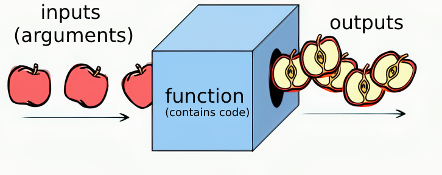

## 5.1 Basic function syntax

You call a function like this:

```r
function_name(argument1 = "value", argument2 = "value")
```

Let’s demonstrate this with the `head()` function, which returns the first few elements of an object.

`head()` normally takes two arguments:

- `x` , the object of interest, and
- `n`, the number of elements to return.

So to return the first three rows of the Ebola dataset, you run:

```r
head(x = ebola_data, n = 3)
```

```
##   id age sex    status date_of_onset date_of_sample district    chiefdom
## 1  1  20   F confirmed    2014-05-18     2014-05-23 Kailahun  Kissi Teng
## 2  2  42   F confirmed    2014-05-20     2014-05-25 Kailahun  Kissi Teng
## 3  3  45   F confirmed    2014-05-20     2014-05-25 Kailahun Kissi Tonge
```

If you put the argument values in the right order, you can skip typing their names:

```r
head(ebola_data, 3)
```

```
##   id age sex    status date_of_onset date_of_sample district    chiefdom
## 1  1  20   F confirmed    2014-05-18     2014-05-23 Kailahun  Kissi Teng
## 2  2  42   F confirmed    2014-05-20     2014-05-25 Kailahun  Kissi Teng
## 3  3  45   F confirmed    2014-05-20     2014-05-25 Kailahun Kissi Tonge
```

Some arguments can be skipped altogether, because they have *default* values. With `head()`, the default value of `n` is 6, so running just `head(ebola_data)` will return the first 6 rows.

```r
head(ebola_data)
```

```
##   id age sex    status date_of_onset date_of_sample district    chiefdom
## 1  1  20   F confirmed    2014-05-18     2014-05-23 Kailahun  Kissi Teng
## 2  2  42   F confirmed    2014-05-20     2014-05-25 Kailahun  Kissi Teng
## 3  3  45   F confirmed    2014-05-20     2014-05-25 Kailahun Kissi Tonge
## 4  4  15   F confirmed    2014-05-21     2014-05-26 Kailahun  Kissi Teng
## 5  5  19   F confirmed    2014-05-21     2014-05-26 Kailahun  Kissi Teng
## 6  6  55   F confirmed    2014-05-21     2014-05-26 Kailahun  Kissi Teng
```

To see the arguments to a function, press the **Tab** key when your cursor is inside the function’s parentheses:

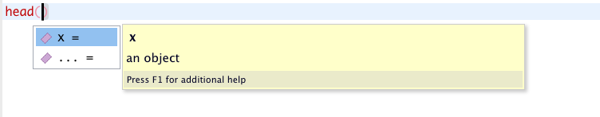

You can also run `?head` to get more details in the Help tab.

## 5.2 Nesting functions

The output of a function can be immediately taken in by another function. This is called function nesting.

For example, the function `trimws()` removes white space from the beginning and end of a string, and the function `tolower()` converts a string to lower case.

```r
trimws("  MUMBAI  ") # lots of white space
```

```
## [1] "MUMBAI"
```

```r
tolower("  MUMBAI  ")
```

```
## [1] "  mumbai  "
```

You can combine these two functions like this:

```r
tolower(trimws("  MUMBAI  "))
```

```
## [1] "mumbai"
```

The output from `trimws()` is immediately passed to `tolower()`. This saves you the need to assign an intermediate object:

```r
# No need for all this
nowhitespace <- trimws("  MUMBAI  ")
tolower(nowhitespace)
```

```
## [1] "mumbai"
```

Function nesting will come in very handy soon.

You have so far seen two options for chaining functions together: function nesting, and assigning intermediate objects. In a later chapter, we will introduce to a third option: “pipes”. This third option is the option you will use most often.

# 6 Packages

As we mentioned previously, R is wonderful because it is user extensible: anyone can create a software *package* that adds new functionality. Most of R’s power comes from these packages.

In the previous lesson, you installed and loaded some packages using the Packages tab in RStudio. Here you will see how to install and load packages with R code.

## 6.1 A first example: {esquisse}

Let’s install a wonderful package, {esquisse}, which provides a nice user interface for creating {ggplot2} graphics. The `install.packages()` handles this.

```r
install.packages("esquisse")
```

Just as you only install an app on your phone once (not every time you turn on your phone), you also only need to install an R package once. Therefore, you should avoid putting `install.packages()` commands in your scripts (since scripts are meant to be run more than once); run these install statements directly in the console instead.

While installation happens only once, you need to *load* a package each time you want to use it. This is done with `library(packagename)`. Try the code below now:

```r
library(esquisse)
```

While a package name does not need to be in quotes for a `library()` call, (e.g. `library(esquisse)` ), it must be in quotes when you are first installing the package (`install.packages("esquisse")`).

Now let’s use the function `esquisser()` from the `{esquisse}` package. Run the code below to open up an interactive plotter that will let you quickly create graphs of your Ebola dataset.

```r
esquisser(ebola_data)
```

In the plotter, drag the `date_of_onset` variable to the x axis box, and the `district` variable to the “fill” box. This should give you an epidemic curve of the number cases over time, colored by region.

[figure not shown]

Nice work!

If you click on the “code” button at the bottom right of the window, you will see the code that generated this plot. You can copy it and run it on your own.

The point of this demonstration of {esquisse} is to show you that there is a lot of power in external R packages. This is a big strength of working with R, an open-source language with a vibrant ecosystem of contributors. Thousands of people are working right now on packages that may be helpful to you one day. The {esquisse} package, for example, is built and actively maintained by a team of wonderful R developers in France; you can see their work [here](https://github.com/dreamRs/esquisse).

And, of course, {esquisse} is just one of many powerful R packages that you will learn to work with in this book. We are excited to introduce you to this big wide world!

You may have noticed that we embrace package names in curly braces, e.g. {esquisse}. This is just a styling convention among R users/teachers. The braces do not *mean* anything.

## 6.2 tidyverse

`{tidyverse}` is a “meta-package” because when you load it, it actually loads several packages under the hood. All these packages are very useful, so you will load tidyverse in most of your data analysis scripts. Install and load it now:

```r
install.packages("tidyverse")
library(tidyverse)
```

The following packages are loaded when you load `{tidyverse}` .

- `{ggplot2}`, for data visualization
- `{readr}`, for data import
- `{tibble}`, for formatting data frames (tables)
- `{tidyr}`, for data tidying
- `{dplyr}`, for data manipulation
- `{purrr}`, for repeating things (iterations)
- `{stringr}`, for string manipulation
- `{forcats}`, for factor manipulation

**Full signifiers**

The *full signifier* of a function includes both the package name and the function name: `package::function()`. You usually do not need to use these full signifiers in your scripts. But there are three situations where it is helpful:

1. If, for some reason, you don’t want to first call `library(package)` before accessing the functions in a package, you can use `package::function()`.

So running:

```r
esquisse::esquisser(ebola_data)
```

is equivalent to:

```r
library(esquisse)
esquisser(ebola_data)
```

2. If there are name conflicts between two packages you have loaded (e.g. they both have a function called “filter”), the package loaded second will hide or *mask* the same-name function from package loaded first. To access that first function, you must use the full signifier. You may have noticed a warning about this when you loaded the `{tidyverse}` meta-package.

   You will likely not need to worry about this for a while.

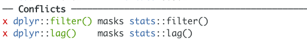

3. Sometimes you simply want to make it clear to yourself or a collaborator what package a function comes from. So you include the full signifier even though you do not *need* to. We will do this often in this course.

## 6.3 pacman

Rather than use two separate functions, `install.packages()` then `library()`, to install then load packages, you can use a single function, `p_load()`, from the {pacman} package to automatically install a package if it is not yet installed, *and* load the package. We encourage this approach in the rest of this course.

Install {pacman} now by running this in your console:

```r
install.packages("pacman")
```

From now on, when you are introduced to a new package, you can simply use, `pacman::p_load(package_name)` to both install and load it.

Try this now for some packages we will use soon:

```r
pacman::p_load(here, rmarkdown)
```

`pacman::p_load()` automatically installs packages. But it would be nice to have some code that automatically installs the {pacman} package itself, if it is missing on a user’s computer.

We can do this with the following code:

```r
if(!require(pacman)) install.packages("pacman")
```

You do not have to understand it at the moment, as it uses some syntax that you have not yet learned. Just note that in future chapters, we will often recommend that you load packages like this:

```r
if(!require(pacman)) install.packages("pacman")
pacman::p_load(here, rmarkdown)
```

The first line will install {pacman} if it is not yet installed. The second line will use `p_load()` function from {pacman} to load the remaining packages (and `pacman::p_load()` installs any packages that are not yet installed).

Phew! Hope your head is still intact.

# 7 Wrapping up

With your new knowledge of R objects, R functions and the packages that functions come from, you are ready, believe it or not, to do basic data analysis in R. We’ll jump into this head first in the next lesson. See you there!

# Contributors

The following team members contributed to this lesson:

- [KENE DAVID NWOSU](https://thegraphcourses.org/members/kendavidn/)  
  Data analyst, the GRAPH Network

  Passionate about education.
- [LAMECK AGASA](https://thegraphcourses.org/members/ondieki)  
  Statistician/Data Scientist

  This is a temporary tagline

# References

Some material in this lesson was adapted from the following sources:

- “File:Apple slicing function.png.” *Wikimedia Commons, the free media repository*. 1 Oct 2021, 04:26 UTC. 20 Mar 2022, 17:27 <https://commons.wikimedia.org/w/index.php?title=File:Apple_slicing_function.png&oldid=594767630>.
- “PsyteachR | Data Skills for Reproducible Research.” 2021. Github.io. 2021. https://psyteachr.github.io/reprores-v2/index.html.
- Douglas, Alex, Deon Roos, Francesca Mancini, Ana Couto, and David Lusseau. 2022. “An Introduction to R.” Intro2r.com. January 27, 2022. https://intro2r.com/.

This work is licensed under the [Creative Commons Attribution Share Alike](https://creativecommons.org/licenses/by-sa/4.0/) license.

[figure not shown]